# DaSH pre-announcement - BCCVL demo (12 Feb)

Michael Sumner

2016-02-04

Hi DaSHers,

*This week (5 February 2016) was open session, Mike and Paola chatted about data sciencey things. Very sorry to the person who could not find us!! The bookings are a bit fluid, so DaSH might be in the flex room, seminar theatre, or upstairs in the lunch room, will tweet last minute details in future [@DataScienceHbt](https://twitter.com/DataScienceHbt/).*

**This post** is to provide an early announcement of next week, when we have a special session on **Species Distribution Modelling made easy.**

Sarah Richmond, of [Griffith University](https://www.griffith.edu.au/) and the [Biodiversity and Climate Change Virtual Laboratory (BCCVL)](https://www.griffith.edu.au/research/research-excellence/climate-resilient-decision-support-toolkit/the-biodiversity-and-climate-change-virtual-laboratory) is visiting and will give a hands-on demonstration of some of the features of the BCCVL. The BCCVL simplifies the process of biodiversity-climate change modelling. It integrates a suite of tools in an online environment where researchers can access data and perform data analysis and modelling.

*When*: from 0900 to 1030 (for a 0915 start)

*Where*: the ground floor teaching lab at [IMAS / ACE CRC Salamanca (‘the Waterfront’)](https://www.google.com.au/maps/place/Antarctic+Climate+%26+Ecosystems+CRC/@-42.8864995,147.3332809,17.25z/data=!4m2!3m1!1s0x0000000000000000:0x6643069d32752fb7).

This demonstration will cater for those interested in using the features of the BCCVL (biodiversity, climate change) as well as those who want to understand more about how a ‘Virtual Laboratory’ can enable and speed up research.

Bring your laptop, and join this hands-on demonstration on Friday 12 February at 9:15 in the Teaching Lab, ground floor at IMAS Salamanca.

[figure not shown]

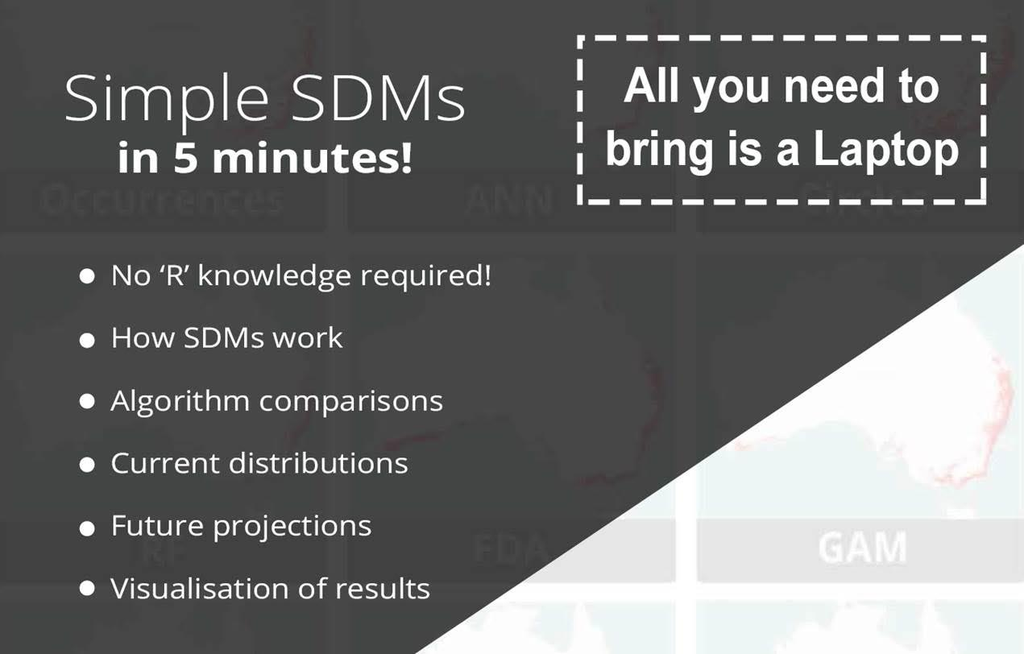